# Risk Factor Analysis

## Outcome Variable

**Outcome Variable:** sstunted

## Predictor Variables

**Intervention Variable:** gagebrth

**Adjustment Set:**

unadjusted

## Stratifying Variables

The analysis was stratified on these variable(s):

- agecat
- studyid
- country

## Data Summary

| agecat | studyid | country | A | n | nA | nAY0 | nAY1 |
| --- | --- | --- | --- | --- | --- | --- | --- |
| Birth | ki1000108-CMC-V-BCS-2002 | INDIA | [273-287) | 90 | 35 | 33 | 2 |
| Birth | ki1000108-CMC-V-BCS-2002 | INDIA | <259 | 90 | 7 | 7 | 0 |
| Birth | ki1000108-CMC-V-BCS-2002 | INDIA | [259-273) | 90 | 22 | 22 | 0 |
| Birth | ki1000108-CMC-V-BCS-2002 | INDIA | >=287 | 90 | 26 | 25 | 1 |
| Birth | ki1000108-IRC | INDIA | [273-287) | 369 | 155 | 151 | 4 |
| Birth | ki1000108-IRC | INDIA | <259 | 369 | 36 | 33 | 3 |
| Birth | ki1000108-IRC | INDIA | [259-273) | 369 | 87 | 85 | 2 |
| Birth | ki1000108-IRC | INDIA | >=287 | 369 | 91 | 85 | 6 |
| Birth | ki1000109-EE | PAKISTAN | [273-287) | 2 | 0 | 0 | 0 |
| Birth | ki1000109-EE | PAKISTAN | <259 | 2 | 1 | 1 | 0 |
| Birth | ki1000109-EE | PAKISTAN | [259-273) | 2 | 1 | 1 | 0 |
| Birth | ki1000109-EE | PAKISTAN | >=287 | 2 | 0 | 0 | 0 |
| Birth | ki1017093c-NIH-Crypto | BANGLADESH | [273-287) | 27 | 12 | 12 | 0 |
| Birth | ki1017093c-NIH-Crypto | BANGLADESH | <259 | 27 | 3 | 3 | 0 |
| Birth | ki1017093c-NIH-Crypto | BANGLADESH | [259-273) | 27 | 11 | 10 | 1 |
| Birth | ki1017093c-NIH-Crypto | BANGLADESH | >=287 | 27 | 1 | 1 | 0 |
| Birth | ki1101329-Keneba | GAMBIA | [273-287) | 1515 | 592 | 586 | 6 |
| Birth | ki1101329-Keneba | GAMBIA | <259 | 1515 | 161 | 149 | 12 |
| Birth | ki1101329-Keneba | GAMBIA | [259-273) | 1515 | 592 | 583 | 9 |
| Birth | ki1101329-Keneba | GAMBIA | >=287 | 1515 | 170 | 168 | 2 |
| Birth | ki1135781-COHORTS | GUATEMALA | [273-287) | 290 | 114 | 114 | 0 |
| Birth | ki1135781-COHORTS | GUATEMALA | <259 | 290 | 49 | 47 | 2 |
| Birth | ki1135781-COHORTS | GUATEMALA | [259-273) | 290 | 46 | 46 | 0 |
| Birth | ki1135781-COHORTS | GUATEMALA | >=287 | 290 | 81 | 81 | 0 |
| Birth | ki1135781-COHORTS | INDIA | [273-287) | 1293 | 510 | 501 | 9 |
| Birth | ki1135781-COHORTS | INDIA | <259 | 1293 | 181 | 169 | 12 |
| Birth | ki1135781-COHORTS | INDIA | [259-273) | 1293 | 289 | 284 | 5 |
| Birth | ki1135781-COHORTS | INDIA | >=287 | 1293 | 313 | 308 | 5 |
| Birth | ki1135781-COHORTS | PHILIPPINES | [273-287) | 3024 | 1178 | 1172 | 6 |
| Birth | ki1135781-COHORTS | PHILIPPINES | <259 | 3024 | 459 | 431 | 28 |

[output cut: 234 more lines]

The following strata were considered:

- agecat: 12 months, studyid: ki1000108-CMC-V-BCS-2002, country: INDIA
- agecat: 12 months, studyid: ki1000108-IRC, country: INDIA
- agecat: 12 months, studyid: ki1000109-EE, country: PAKISTAN
- agecat: 12 months, studyid: ki1017093c-NIH-Crypto, country: BANGLADESH
- agecat: 12 months, studyid: ki1066203-TanzaniaChild2, country: TANZANIA, UNITED REPUBLIC OF
- agecat: 12 months, studyid: ki1101329-Keneba, country: GAMBIA
- agecat: 12 months, studyid: ki1113344-GMS-Nepal, country: NEPAL
- agecat: 12 months, studyid: ki1135781-COHORTS, country: GUATEMALA
- agecat: 12 months, studyid: ki1135781-COHORTS, country: INDIA
- agecat: 12 months, studyid: ki1135781-COHORTS, country: PHILIPPINES
- agecat: 18 months, studyid: ki1000108-CMC-V-BCS-2002, country: INDIA
- agecat: 18 months, studyid: ki1000108-IRC, country: INDIA
- agecat: 18 months, studyid: ki1000109-EE, country: PAKISTAN
- agecat: 18 months, studyid: ki1017093c-NIH-Crypto, country: BANGLADESH
- agecat: 18 months, studyid: ki1066203-TanzaniaChild2, country: TANZANIA, UNITED REPUBLIC OF
- agecat: 18 months, studyid: ki1101329-Keneba, country: GAMBIA
- agecat: 18 months, studyid: ki1113344-GMS-Nepal, country: NEPAL
- agecat: 18 months, studyid: ki1135781-COHORTS, country: GUATEMALA
- agecat: 18 months, studyid: ki1135781-COHORTS, country: PHILIPPINES
- agecat: 24 months, studyid: ki1000108-CMC-V-BCS-2002, country: INDIA
- agecat: 24 months, studyid: ki1000108-IRC, country: INDIA
- agecat: 24 months, studyid: ki1017093c-NIH-Crypto, country: BANGLADESH
- agecat: 24 months, studyid: ki1066203-TanzaniaChild2, country: TANZANIA, UNITED REPUBLIC OF
- agecat: 24 months, studyid: ki1101329-Keneba, country: GAMBIA
- agecat: 24 months, studyid: ki1113344-GMS-Nepal, country: NEPAL
- agecat: 24 months, studyid: ki1135781-COHORTS, country: GUATEMALA
- agecat: 24 months, studyid: ki1135781-COHORTS, country: INDIA
- agecat: 24 months, studyid: ki1135781-COHORTS, country: PHILIPPINES
- agecat: 3 months, studyid: ki1000108-CMC-V-BCS-2002, country: INDIA
- agecat: 3 months, studyid: ki1000108-IRC, country: INDIA
- agecat: 3 months, studyid: ki1000109-EE, country: PAKISTAN
- agecat: 3 months, studyid: ki1017093c-NIH-Crypto, country: BANGLADESH
- agecat: 3 months, studyid: ki1066203-TanzaniaChild2, country: TANZANIA, UNITED REPUBLIC OF
- agecat: 3 months, studyid: ki1101329-Keneba, country: GAMBIA
- agecat: 3 months, studyid: ki1113344-GMS-Nepal, country: NEPAL
- agecat: 3 months, studyid: ki1135781-COHORTS, country: GUATEMALA
- agecat: 3 months, studyid: ki1135781-COHORTS, country: INDIA
- agecat: 3 months, studyid: ki1135781-COHORTS, country: PHILIPPINES
- agecat: 6 months, studyid: ki1000108-CMC-V-BCS-2002, country: INDIA
- agecat: 6 months, studyid: ki1000108-IRC, country: INDIA
- agecat: 6 months, studyid: ki1000109-EE, country: PAKISTAN
- agecat: 6 months, studyid: ki1017093c-NIH-Crypto, country: BANGLADESH
- agecat: 6 months, studyid: ki1066203-TanzaniaChild2, country: TANZANIA, UNITED REPUBLIC OF
- agecat: 6 months, studyid: ki1101329-Keneba, country: GAMBIA
- agecat: 6 months, studyid: ki1113344-GMS-Nepal, country: NEPAL
- agecat: 6 months, studyid: ki1135781-COHORTS, country: GUATEMALA
- agecat: 6 months, studyid: ki1135781-COHORTS, country: INDIA
- agecat: 6 months, studyid: ki1135781-COHORTS, country: PHILIPPINES
- agecat: 9 months, studyid: ki1000108-CMC-V-BCS-2002, country: INDIA
- agecat: 9 months, studyid: ki1000108-IRC, country: INDIA
- agecat: 9 months, studyid: ki1000109-EE, country: PAKISTAN
- agecat: 9 months, studyid: ki1017093c-NIH-Crypto, country: BANGLADESH
- agecat: 9 months, studyid: ki1066203-TanzaniaChild2, country: TANZANIA, UNITED REPUBLIC OF
- agecat: 9 months, studyid: ki1101329-Keneba, country: GAMBIA
- agecat: 9 months, studyid: ki1113344-GMS-Nepal, country: NEPAL
- agecat: 9 months, studyid: ki1135781-COHORTS, country: GUATEMALA
- agecat: 9 months, studyid: ki1135781-COHORTS, country: INDIA
- agecat: 9 months, studyid: ki1135781-COHORTS, country: PHILIPPINES
- agecat: Birth, studyid: ki1000108-CMC-V-BCS-2002, country: INDIA
- agecat: Birth, studyid: ki1000108-IRC, country: INDIA
- agecat: Birth, studyid: ki1000109-EE, country: PAKISTAN
- agecat: Birth, studyid: ki1017093c-NIH-Crypto, country: BANGLADESH
- agecat: Birth, studyid: ki1101329-Keneba, country: GAMBIA
- agecat: Birth, studyid: ki1135781-COHORTS, country: GUATEMALA
- agecat: Birth, studyid: ki1135781-COHORTS, country: INDIA
- agecat: Birth, studyid: ki1135781-COHORTS, country: PHILIPPINES

### Dropped Strata

Some strata were dropped due to rare outcomes:

- agecat: Birth, studyid: ki1000108-CMC-V-BCS-2002, country: INDIA
- agecat: Birth, studyid: ki1000108-IRC, country: INDIA
- agecat: Birth, studyid: ki1000109-EE, country: PAKISTAN
- agecat: Birth, studyid: ki1017093c-NIH-Crypto, country: BANGLADESH
- agecat: Birth, studyid: ki1101329-Keneba, country: GAMBIA
- agecat: Birth, studyid: ki1135781-COHORTS, country: GUATEMALA
- agecat: Birth, studyid: ki1135781-COHORTS, country: PHILIPPINES
- agecat: 3 months, studyid: ki1000109-EE, country: PAKISTAN
- agecat: 3 months, studyid: ki1017093c-NIH-Crypto, country: BANGLADESH
- agecat: 3 months, studyid: ki1066203-TanzaniaChild2, country: TANZANIA, UNITED REPUBLIC OF
- agecat: 3 months, studyid: ki1101329-Keneba, country: GAMBIA
- agecat: 3 months, studyid: ki1113344-GMS-Nepal, country: NEPAL
- agecat: 6 months, studyid: ki1000108-IRC, country: INDIA
- agecat: 6 months, studyid: ki1000109-EE, country: PAKISTAN
- agecat: 6 months, studyid: ki1017093c-NIH-Crypto, country: BANGLADESH
- agecat: 6 months, studyid: ki1066203-TanzaniaChild2, country: TANZANIA, UNITED REPUBLIC OF
- agecat: 6 months, studyid: ki1101329-Keneba, country: GAMBIA
- agecat: 6 months, studyid: ki1113344-GMS-Nepal, country: NEPAL
- agecat: 9 months, studyid: ki1000108-IRC, country: INDIA
- agecat: 9 months, studyid: ki1000109-EE, country: PAKISTAN
- agecat: 9 months, studyid: ki1017093c-NIH-Crypto, country: BANGLADESH
- agecat: 9 months, studyid: ki1066203-TanzaniaChild2, country: TANZANIA, UNITED REPUBLIC OF
- agecat: 9 months, studyid: ki1113344-GMS-Nepal, country: NEPAL
- agecat: 12 months, studyid: ki1000108-IRC, country: INDIA
- agecat: 12 months, studyid: ki1000109-EE, country: PAKISTAN
- agecat: 12 months, studyid: ki1017093c-NIH-Crypto, country: BANGLADESH
- agecat: 12 months, studyid: ki1113344-GMS-Nepal, country: NEPAL
- agecat: 18 months, studyid: ki1000109-EE, country: PAKISTAN
- agecat: 18 months, studyid: ki1017093c-NIH-Crypto, country: BANGLADESH
- agecat: 18 months, studyid: ki1113344-GMS-Nepal, country: NEPAL
- agecat: 24 months, studyid: ki1017093c-NIH-Crypto, country: BANGLADESH
- agecat: 24 months, studyid: ki1066203-TanzaniaChild2, country: TANZANIA, UNITED REPUBLIC OF
- agecat: 24 months, studyid: ki1113344-GMS-Nepal, country: NEPAL

## Methods Detail

We’re interested in the causal parameters $E[Y_a]$ for all values of $a \in \mathcal{A}$. These parameters represent the mean outcome if, possibly contrary to fact, we intervened to set all units to have $A=a$. Under the randomization and positivity assumptions, these are identified by the statistical parameters $\psi_a=E_W[E_{Y|A,W}(Y|A=a,W)]$. In addition, we’re interested in the mean of $Y$, $E[Y]$ under no intervention (the observed mean). We will estimate these parameters by using SuperLearner to fit the relevant likelihood factors – $E_{Y|A,W}(Y|A=a,W)$ and $p(A=a|W)$, and then updating our likelihood fit using a joint TMLE.

For unadjusted analyses ($W=\{\}$), initial likelihoods were estimated using Lrnr_glm to estimate the simple $E(Y|A)$ and Lrnr_mean to estimate $p(A)$. For adjusted analyses, a small library containing Lrnr_glmnet, Lrnr_xgboost, and Lrnr_mean was used.

Having estimated these parameters, we will then use the delta method to estimate relative risks and attributable risks relative to a prespecified baseline level of $A$.

# Results Detail

## Results Plots

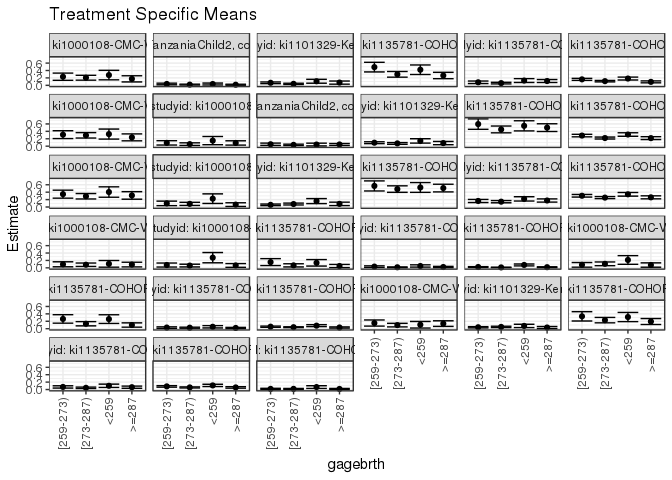

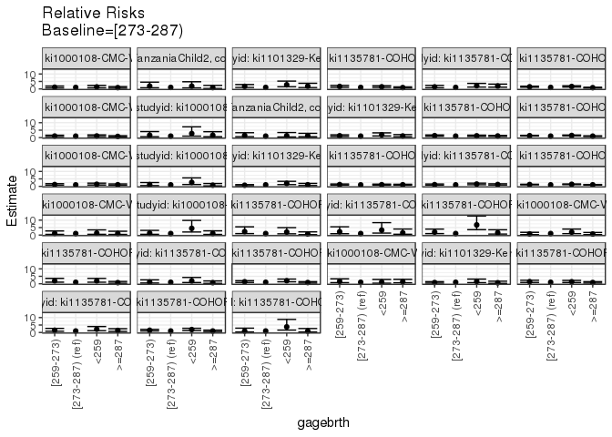

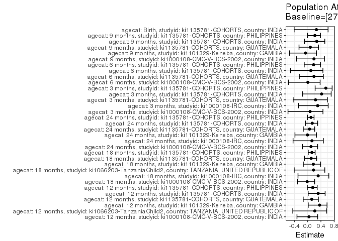

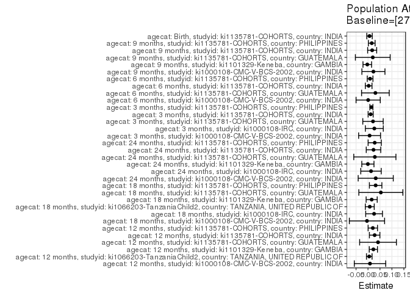

## Results Table

### Parameter: TSM

| agecat | studyid | country | intervention_level | baseline_level | estimate | ci_lower | ci_upper |
| --- | --- | --- | --- | --- | --- | --- | --- |
| Birth | ki1135781-COHORTS | INDIA | [273-287) | NA | 0.0176471 | 0.0062156 | 0.0290785 |
| Birth | ki1135781-COHORTS | INDIA | <259 | NA | 0.0662983 | 0.0300380 | 0.1025587 |
| Birth | ki1135781-COHORTS | INDIA | [259-273) | NA | 0.0173010 | 0.0022622 | 0.0323398 |
| Birth | ki1135781-COHORTS | INDIA | >=287 | NA | 0.0159744 | 0.0020794 | 0.0298695 |
| 3 months | ki1000108-CMC-V-BCS-2002 | INDIA | [273-287) | NA | 0.0845070 | 0.0386910 | 0.1303231 |
| 3 months | ki1000108-CMC-V-BCS-2002 | INDIA | <259 | NA | 0.1086957 | 0.0186158 | 0.1987755 |
| 3 months | ki1000108-CMC-V-BCS-2002 | INDIA | [259-273) | NA | 0.0958904 | 0.0282472 | 0.1635337 |
| 3 months | ki1000108-CMC-V-BCS-2002 | INDIA | >=287 | NA | 0.0886076 | 0.0258506 | 0.1513646 |
| 3 months | ki1000108-IRC | INDIA | [273-287) | NA | 0.0613497 | 0.0244626 | 0.0982368 |
| 3 months | ki1000108-IRC | INDIA | <259 | NA | 0.2750000 | 0.1364472 | 0.4135528 |
| 3 months | ki1000108-IRC | INDIA | [259-273) | NA | 0.0760870 | 0.0218386 | 0.1303353 |
| 3 months | ki1000108-IRC | INDIA | >=287 | NA | 0.0652174 | 0.0146986 | 0.1157362 |
| 3 months | ki1135781-COHORTS | GUATEMALA | [273-287) | NA | 0.0671642 | 0.0247232 | 0.1096051 |
| 3 months | ki1135781-COHORTS | GUATEMALA | <259 | NA | 0.1355932 | 0.0481114 | 0.2230751 |
| 3 months | ki1135781-COHORTS | GUATEMALA | [259-273) | NA | 0.1551724 | 0.0618592 | 0.2484856 |
| 3 months | ki1135781-COHORTS | GUATEMALA | >=287 | NA | 0.0495050 | 0.0071402 | 0.0918697 |
| 3 months | ki1135781-COHORTS | INDIA | [273-287) | NA | 0.0152091 | 0.0047465 | 0.0256718 |
| 3 months | ki1135781-COHORTS | INDIA | <259 | NA | 0.0505051 | 0.0199915 | 0.0810186 |
| 3 months | ki1135781-COHORTS | INDIA | [259-273) | NA | 0.0336700 | 0.0131481 | 0.0541919 |
| 3 months | ki1135781-COHORTS | INDIA | >=287 | NA | 0.0224359 | 0.0059968 | 0.0388750 |
| 3 months | ki1135781-COHORTS | PHILIPPINES | [273-287) | NA | 0.0115453 | 0.0053046 | 0.0177860 |
| 3 months | ki1135781-COHORTS | PHILIPPINES | <259 | NA | 0.0783848 | 0.0527060 | 0.1040636 |
| 3 months | ki1135781-COHORTS | PHILIPPINES | [259-273) | NA | 0.0227560 | 0.0123619 | 0.0331501 |
| 3 months | ki1135781-COHORTS | PHILIPPINES | >=287 | NA | 0.0175781 | 0.0061933 | 0.0289629 |
| 6 months | ki1000108-CMC-V-BCS-2002 | INDIA | [273-287) | NA | 0.1088435 | 0.0584245 | 0.1592626 |
| 6 months | ki1000108-CMC-V-BCS-2002 | INDIA | <259 | NA | 0.2127660 | 0.0955926 | 0.3299393 |
| 6 months | ki1000108-CMC-V-BCS-2002 | INDIA | [259-273) | NA | 0.0810811 | 0.0187998 | 0.1433623 |
| 6 months | ki1000108-CMC-V-BCS-2002 | INDIA | >=287 | NA | 0.0759494 | 0.0174473 | 0.1344514 |
| 6 months | ki1135781-COHORTS | GUATEMALA | [273-287) | NA | 0.1333333 | 0.0759080 | 0.1907586 |
| 6 months | ki1135781-COHORTS | GUATEMALA | <259 | NA | 0.2592593 | 0.1422074 | 0.3763111 |

[output cut: 102 more lines]

### Parameter: E(Y)

| agecat | studyid | country | intervention_level | baseline_level | estimate | ci_lower | ci_upper |
| --- | --- | --- | --- | --- | --- | --- | --- |
| Birth | ki1135781-COHORTS | INDIA | NA | NA | 0.0239753 | 0.0230435 | 0.0249070 |
| 3 months | ki1000108-CMC-V-BCS-2002 | INDIA | NA | NA | 0.0911765 | 0.0903090 | 0.0920439 |
| 3 months | ki1000108-IRC | INDIA | NA | NA | 0.0878553 | 0.0814905 | 0.0942201 |
| 3 months | ki1135781-COHORTS | GUATEMALA | NA | NA | 0.0880682 | 0.0837376 | 0.0923988 |
| 3 months | ki1135781-COHORTS | INDIA | NA | NA | 0.0262566 | 0.0255963 | 0.0269168 |
| 3 months | ki1135781-COHORTS | PHILIPPINES | NA | NA | 0.0256140 | 0.0247901 | 0.0264379 |
| 6 months | ki1000108-CMC-V-BCS-2002 | INDIA | NA | NA | 0.1095101 | 0.1049499 | 0.1140703 |
| 6 months | ki1135781-COHORTS | GUATEMALA | NA | NA | 0.1642651 | 0.1571013 | 0.1714290 |
| 6 months | ki1135781-COHORTS | INDIA | NA | NA | 0.0297256 | 0.0291954 | 0.0302558 |
| 6 months | ki1135781-COHORTS | PHILIPPINES | NA | NA | 0.0487533 | 0.0481560 | 0.0493506 |
| 9 months | ki1000108-CMC-V-BCS-2002 | INDIA | NA | NA | 0.1191860 | 0.1166985 | 0.1216736 |
| 9 months | ki1101329-Keneba | GAMBIA | NA | NA | 0.0450254 | 0.0444352 | 0.0456156 |
| 9 months | ki1135781-COHORTS | GUATEMALA | NA | NA | 0.2507553 | 0.2449870 | 0.2565236 |
| 9 months | ki1135781-COHORTS | INDIA | NA | NA | 0.0635983 | 0.0625528 | 0.0646439 |
| 9 months | ki1135781-COHORTS | PHILIPPINES | NA | NA | 0.0724638 | 0.0717050 | 0.0732225 |
| 12 months | ki1000108-CMC-V-BCS-2002 | INDIA | NA | NA | 0.2138728 | 0.2105532 | 0.2171925 |
| 12 months | ki1066203-TanzaniaChild2 | TANZANIA, UNITED REPUBLIC OF | NA | NA | 0.0243363 | 0.0238810 | 0.0247915 |
| 12 months | ki1101329-Keneba | GAMBIA | NA | NA | 0.0623077 | 0.0611424 | 0.0634729 |
| 12 months | ki1135781-COHORTS | GUATEMALA | NA | NA | 0.3389831 | 0.3301991 | 0.3477670 |
| 12 months | ki1135781-COHORTS | INDIA | NA | NA | 0.0875000 | 0.0858921 | 0.0891079 |
| 12 months | ki1135781-COHORTS | PHILIPPINES | NA | NA | 0.1330472 | 0.1318024 | 0.1342920 |
| 18 months | ki1000108-CMC-V-BCS-2002 | INDIA | NA | NA | 0.2881844 | 0.2850237 | 0.2913452 |
| 18 months | ki1000108-IRC | INDIA | NA | NA | 0.0803109 | 0.0774754 | 0.0831463 |
| 18 months | ki1066203-TanzaniaChild2 | TANZANIA, UNITED REPUBLIC OF | NA | NA | 0.0422993 | 0.0418717 | 0.0427270 |
| 18 months | ki1101329-Keneba | GAMBIA | NA | NA | 0.0899308 | 0.0888766 | 0.0909851 |
| 18 months | ki1135781-COHORTS | GUATEMALA | NA | NA | 0.5050167 | 0.4990943 | 0.5109392 |
| 18 months | ki1135781-COHORTS | PHILIPPINES | NA | NA | 0.2513153 | 0.2497675 | 0.2528630 |
| 24 months | ki1000108-CMC-V-BCS-2002 | INDIA | NA | NA | 0.3228571 | 0.3188246 | 0.3268897 |
| 24 months | ki1000108-IRC | INDIA | NA | NA | 0.0974359 | 0.0929979 | 0.1018739 |
| 24 months | ki1101329-Keneba | GAMBIA | NA | NA | 0.0795848 | 0.0779456 | 0.0812239 |
| 24 months | ki1135781-COHORTS | GUATEMALA | NA | NA | 0.5125000 | 0.5092861 | 0.5157139 |
| 24 months | ki1135781-COHORTS | INDIA | NA | NA | 0.1666667 | 0.1652888 | 0.1680445 |
| 24 months | ki1135781-COHORTS | PHILIPPINES | NA | NA | 0.2817657 | 0.2804647 | 0.2830666 |

### Parameter: RR

| agecat | studyid | country | intervention_level | baseline_level | estimate | ci_lower | ci_upper |
| --- | --- | --- | --- | --- | --- | --- | --- |
| Birth | ki1135781-COHORTS | INDIA | [273-287) | [273-287) | 1.0000000 | 1.0000000 | 1.000000 |
| Birth | ki1135781-COHORTS | INDIA | <259 | [273-287) | 3.7569061 | 1.6093080 | 8.770442 |
| Birth | ki1135781-COHORTS | INDIA | [259-273) | [273-287) | 0.9803922 | 0.3315849 | 2.898711 |
| Birth | ki1135781-COHORTS | INDIA | >=287 | [273-287) | 0.9052183 | 0.3060159 | 2.677704 |
| 3 months | ki1000108-CMC-V-BCS-2002 | INDIA | [273-287) | [273-287) | 1.0000000 | 1.0000000 | 1.000000 |
| 3 months | ki1000108-CMC-V-BCS-2002 | INDIA | <259 | [273-287) | 1.2862319 | 0.4777805 | 3.462662 |
| 3 months | ki1000108-CMC-V-BCS-2002 | INDIA | [259-273) | [273-287) | 1.1347032 | 0.4661153 | 2.762302 |
| 3 months | ki1000108-CMC-V-BCS-2002 | INDIA | >=287 | [273-287) | 1.0485232 | 0.4297462 | 2.558256 |
| 3 months | ki1000108-IRC | INDIA | [273-287) | [273-287) | 1.0000000 | 1.0000000 | 1.000000 |
| 3 months | ki1000108-IRC | INDIA | <259 | [273-287) | 4.4825000 | 2.0456892 | 9.822023 |
| 3 months | ki1000108-IRC | INDIA | [259-273) | [273-287) | 1.2402174 | 0.4880334 | 3.151709 |
| 3 months | ki1000108-IRC | INDIA | >=287 | [273-287) | 1.0630435 | 0.3987378 | 2.834097 |
| 3 months | ki1135781-COHORTS | GUATEMALA | [273-287) | [273-287) | 1.0000000 | 1.0000000 | 1.000000 |
| 3 months | ki1135781-COHORTS | GUATEMALA | <259 | [273-287) | 2.0188324 | 0.8182730 | 4.980837 |
| 3 months | ki1135781-COHORTS | GUATEMALA | [259-273) | [273-287) | 2.3103448 | 0.9656921 | 5.527324 |
| 3 months | ki1135781-COHORTS | GUATEMALA | >=287 | [273-287) | 0.7370737 | 0.2543993 | 2.135531 |
| 3 months | ki1135781-COHORTS | INDIA | [273-287) | [273-287) | 1.0000000 | 1.0000000 | 1.000000 |
| 3 months | ki1135781-COHORTS | INDIA | <259 | [273-287) | 3.3207071 | 1.3292520 | 8.295715 |
| 3 months | ki1135781-COHORTS | INDIA | [259-273) | [273-287) | 2.2138047 | 0.8830474 | 5.550020 |
| 3 months | ki1135781-COHORTS | INDIA | >=287 | [273-287) | 1.4751603 | 0.5399532 | 4.030160 |
| 3 months | ki1135781-COHORTS | PHILIPPINES | [273-287) | [273-287) | 1.0000000 | 1.0000000 | 1.000000 |
| 3 months | ki1135781-COHORTS | PHILIPPINES | <259 | [273-287) | 6.7893294 | 3.6084749 | 12.774093 |
| 3 months | ki1135781-COHORTS | PHILIPPINES | [259-273) | [273-287) | 1.9710201 | 0.9712860 | 3.999770 |
| 3 months | ki1135781-COHORTS | PHILIPPINES | >=287 | [273-287) | 1.5225361 | 0.6549329 | 3.539471 |
| 6 months | ki1000108-CMC-V-BCS-2002 | INDIA | [273-287) | [273-287) | 1.0000000 | 1.0000000 | 1.000000 |
| 6 months | ki1000108-CMC-V-BCS-2002 | INDIA | <259 | [273-287) | 1.9547872 | 0.9518515 | 4.014485 |
| 6 months | ki1000108-CMC-V-BCS-2002 | INDIA | [259-273) | [273-287) | 0.7449324 | 0.3037769 | 1.826750 |
| 6 months | ki1000108-CMC-V-BCS-2002 | INDIA | >=287 | [273-287) | 0.6977848 | 0.2840289 | 1.714275 |
| 6 months | ki1135781-COHORTS | GUATEMALA | [273-287) | [273-287) | 1.0000000 | 1.0000000 | 1.000000 |
| 6 months | ki1135781-COHORTS | GUATEMALA | <259 | [273-287) | 1.9444444 | 1.0418634 | 3.628944 |

[output cut: 102 more lines]

### Parameter: PAR

| agecat | studyid | country | intervention_level | baseline_level | estimate | ci_lower | ci_upper |
| --- | --- | --- | --- | --- | --- | --- | --- |
| Birth | ki1135781-COHORTS | INDIA | [273-287) | NA | 0.0063282 | -0.0051412 | 0.0177975 |
| 3 months | ki1000108-CMC-V-BCS-2002 | INDIA | [273-287) | NA | 0.0066694 | -0.0391548 | 0.0524937 |
| 3 months | ki1000108-IRC | INDIA | [273-287) | NA | 0.0265056 | -0.0109266 | 0.0639378 |
| 3 months | ki1135781-COHORTS | GUATEMALA | [273-287) | NA | 0.0209040 | -0.0217573 | 0.0635653 |
| 3 months | ki1135781-COHORTS | INDIA | [273-287) | NA | 0.0110474 | 0.0005640 | 0.0215309 |
| 3 months | ki1135781-COHORTS | PHILIPPINES | [273-287) | NA | 0.0140687 | 0.0077739 | 0.0203636 |
| 6 months | ki1000108-CMC-V-BCS-2002 | INDIA | [273-287) | NA | 0.0006665 | -0.0499583 | 0.0512914 |
| 6 months | ki1135781-COHORTS | GUATEMALA | [273-287) | NA | 0.0309318 | -0.0269386 | 0.0888022 |
| 6 months | ki1135781-COHORTS | INDIA | [273-287) | NA | 0.0028025 | -0.0111246 | 0.0167297 |
| 6 months | ki1135781-COHORTS | PHILIPPINES | [273-287) | NA | 0.0087533 | -0.0031167 | 0.0206232 |
| 9 months | ki1000108-CMC-V-BCS-2002 | INDIA | [273-287) | NA | 0.0226343 | -0.0255723 | 0.0708410 |
| 9 months | ki1101329-Keneba | GAMBIA | [273-287) | NA | -0.0029451 | -0.0209525 | 0.0150624 |
| 9 months | ki1135781-COHORTS | GUATEMALA | [273-287) | NA | 0.0199861 | -0.0527785 | 0.0927506 |
| 9 months | ki1135781-COHORTS | INDIA | [273-287) | NA | 0.0173798 | -0.0015185 | 0.0362782 |
| 9 months | ki1135781-COHORTS | PHILIPPINES | [273-287) | NA | 0.0156993 | 0.0017266 | 0.0296721 |
| 12 months | ki1000108-CMC-V-BCS-2002 | INDIA | [273-287) | NA | 0.0083934 | -0.0573257 | 0.0741125 |
| 12 months | ki1066203-TanzaniaChild2 | TANZANIA, UNITED REPUBLIC OF | [273-287) | NA | 0.0052523 | -0.0064756 | 0.0169802 |
| 12 months | ki1101329-Keneba | GAMBIA | [273-287) | NA | 0.0224671 | 0.0053116 | 0.0396225 |
| 12 months | ki1135781-COHORTS | GUATEMALA | [273-287) | NA | 0.0418816 | -0.0349742 | 0.1187374 |
| 12 months | ki1135781-COHORTS | INDIA | [273-287) | NA | 0.0277655 | 0.0058484 | 0.0496826 |
| 12 months | ki1135781-COHORTS | PHILIPPINES | [273-287) | NA | 0.0201601 | 0.0005129 | 0.0398073 |
| 18 months | ki1000108-CMC-V-BCS-2002 | INDIA | [273-287) | NA | -0.0043326 | -0.0780465 | 0.0693813 |
| 18 months | ki1000108-IRC | INDIA | [273-287) | NA | 0.0254328 | -0.0095827 | 0.0604484 |
| 18 months | ki1066203-TanzaniaChild2 | TANZANIA, UNITED REPUBLIC OF | [273-287) | NA | 0.0074468 | -0.0111808 | 0.0260744 |
| 18 months | ki1101329-Keneba | GAMBIA | [273-287) | NA | 0.0153340 | -0.0078212 | 0.0384893 |
| 18 months | ki1135781-COHORTS | GUATEMALA | [273-287) | NA | 0.0536893 | -0.0384063 | 0.1457848 |
| 18 months | ki1135781-COHORTS | PHILIPPINES | [273-287) | NA | 0.0319538 | 0.0058744 | 0.0580332 |
| 24 months | ki1000108-CMC-V-BCS-2002 | INDIA | [273-287) | NA | 0.0323166 | -0.0410440 | 0.1056772 |
| 24 months | ki1000108-IRC | INDIA | [273-287) | NA | 0.0125874 | -0.0302161 | 0.0553909 |
| 24 months | ki1101329-Keneba | GAMBIA | [273-287) | NA | -0.0005068 | -0.0260196 | 0.0250061 |
| 24 months | ki1135781-COHORTS | GUATEMALA | [273-287) | NA | 0.0286290 | -0.0595265 | 0.1167846 |
| 24 months | ki1135781-COHORTS | INDIA | [273-287) | NA | 0.0229773 | -0.0073606 | 0.0533153 |
| 24 months | ki1135781-COHORTS | PHILIPPINES | [273-287) | NA | 0.0281122 | 0.0005237 | 0.0557008 |

### Parameter: PAF

| agecat | studyid | country | intervention_level | baseline_level | estimate | ci_lower | ci_upper |
| --- | --- | --- | --- | --- | --- | --- | --- |
| Birth | ki1135781-COHORTS | INDIA | [273-287) | NA | 0.2639469 | -0.4084550 | 0.6153415 |
| 3 months | ki1000108-CMC-V-BCS-2002 | INDIA | [273-287) | NA | 0.0731486 | -0.5940499 | 0.4610874 |
| 3 months | ki1000108-IRC | INDIA | [273-287) | NA | 0.3016961 | -0.2795485 | 0.6189060 |
| 3 months | ki1135781-COHORTS | GUATEMALA | [273-287) | NA | 0.2373616 | -0.4374023 | 0.5953691 |
| 3 months | ki1135781-COHORTS | INDIA | [273-287) | NA | 0.4207496 | -0.1529908 | 0.7089907 |
| 3 months | ki1135781-COHORTS | PHILIPPINES | [273-287) | NA | 0.5492591 | 0.2253644 | 0.7377253 |
| 6 months | ki1000108-CMC-V-BCS-2002 | INDIA | [273-287) | NA | 0.0060866 | -0.5824709 | 0.3757460 |
| 6 months | ki1135781-COHORTS | GUATEMALA | [273-287) | NA | 0.1883041 | -0.2513997 | 0.4735093 |
| 6 months | ki1135781-COHORTS | INDIA | [273-287) | NA | 0.0942801 | -0.5192281 | 0.4600359 |
| 6 months | ki1135781-COHORTS | PHILIPPINES | [273-287) | NA | 0.1795420 | -0.1037731 | 0.3901361 |
| 9 months | ki1000108-CMC-V-BCS-2002 | INDIA | [273-287) | NA | 0.1899075 | -0.3343546 | 0.5081893 |
| 9 months | ki1101329-Keneba | GAMBIA | [273-287) | NA | -0.0654089 | -0.5508011 | 0.2680582 |
| 9 months | ki1135781-COHORTS | GUATEMALA | [273-287) | NA | 0.0797034 | -0.2612483 | 0.3284861 |
| 9 months | ki1135781-COHORTS | INDIA | [273-287) | NA | 0.2732751 | -0.0935064 | 0.5170315 |
| 9 months | ki1135781-COHORTS | PHILIPPINES | [273-287) | NA | 0.2166509 | -0.0018373 | 0.3874895 |
| 12 months | ki1000108-CMC-V-BCS-2002 | INDIA | [273-287) | NA | 0.0392447 | -0.3228203 | 0.3022101 |
| 12 months | ki1066203-TanzaniaChild2 | TANZANIA, UNITED REPUBLIC OF | [273-287) | NA | 0.2158223 | -0.4495369 | 0.5757717 |
| 12 months | ki1101329-Keneba | GAMBIA | [273-287) | NA | 0.3605824 | 0.0170363 | 0.5840590 |
| 12 months | ki1135781-COHORTS | GUATEMALA | [273-287) | NA | 0.1235507 | -0.1347552 | 0.3230581 |
| 12 months | ki1135781-COHORTS | INDIA | [273-287) | NA | 0.3173198 | 0.0152311 | 0.5267395 |
| 12 months | ki1135781-COHORTS | PHILIPPINES | [273-287) | NA | 0.1515259 | -0.0096759 | 0.2869907 |
| 18 months | ki1000108-CMC-V-BCS-2002 | INDIA | [273-287) | NA | -0.0150340 | -0.3059461 | 0.2110746 |
| 18 months | ki1000108-IRC | INDIA | [273-287) | NA | 0.3166798 | -0.2919514 | 0.6385882 |
| 18 months | ki1066203-TanzaniaChild2 | TANZANIA, UNITED REPUBLIC OF | [273-287) | NA | 0.1760500 | -0.4060430 | 0.5171602 |
| 18 months | ki1101329-Keneba | GAMBIA | [273-287) | NA | 0.1705094 | -0.1312942 | 0.3917986 |
| 18 months | ki1135781-COHORTS | GUATEMALA | [273-287) | NA | 0.1063119 | -0.0958951 | 0.2712091 |
| 18 months | ki1135781-COHORTS | PHILIPPINES | [273-287) | NA | 0.1271462 | 0.0170030 | 0.2249480 |
| 24 months | ki1000108-CMC-V-BCS-2002 | INDIA | [273-287) | NA | 0.1000957 | -0.1583048 | 0.3008508 |
| 24 months | ki1000108-IRC | INDIA | [273-287) | NA | 0.1291866 | -0.4412148 | 0.4738356 |
| 24 months | ki1101329-Keneba | GAMBIA | [273-287) | NA | -0.0063675 | -0.3838950 | 0.2681702 |
| 24 months | ki1135781-COHORTS | GUATEMALA | [273-287) | NA | 0.0558615 | -0.1328001 | 0.2131026 |
| 24 months | ki1135781-COHORTS | INDIA | [273-287) | NA | 0.1378641 | -0.0647476 | 0.3019206 |
| 24 months | ki1135781-COHORTS | PHILIPPINES | [273-287) | NA | 0.0997717 | -0.0036416 | 0.1925294 |